# Titanic - Regressão Logítisca Binária.

### **1. Explicando o Desafio**

O naufrágio do Titanic é um dos naufrágios mais infames da história.

Em 15 de abril de 1912, durante sua viagem inaugural, o amplamente considerado “inafundável” RMS Titanic afundou após colidir com um iceberg. Infelizmente, não havia botes salva-vidas suficientes para todos a bordo, resultando na morte de 1.502 dos 2.224 passageiros e tripulantes.

Embora houvesse algum elemento de sorte envolvido na sobrevivência, parece que alguns grupos de pessoas eram mais propensos a sobreviver do que outros.

Neste desafio, pedimos que você construa um modelo preditivo que responda à pergunta: “que tipo de pessoa tem maior probabilidade de sobreviver?” usando os dados do passageiro (ou seja, nome, idade, sexo, classe socioeconômica, etc).

A competição é simples: use o aprendizado de máquina para criar um modelo que preveja quais passageiros sobreviveram ao naufrágio do Titanic.

### **2.Conhecendo a base de dados.**

Primeiro a ser feito é entender qual a distribuição dos dados, conhecer a sua estrutura, ver quais são os tipos de variáveis. Em seguindo é preciso fazer uma extração de informações estatísticas sobre o banco o de dados.

```r
# Carregando todos os pacotes para esse exemplo

pacotes <- c("plotly","tidyverse","knitr","kableExtra","fastDummies","rgl","car",
             "reshape2","jtools","stargazer","lmtest","caret","pROC","ROCR","nnet",
             "magick","cowplot","globals","equatiomatic", "fastDummies", "gghalves","ggdist", "tidyquant")

options(rgl.debug = TRUE)

if(sum(as.numeric(!pacotes %in% installed.packages())) != 0){
  instalador <- pacotes[!pacotes %in% installed.packages()]
  for(i in 1:length(instalador)) {
    install.packages(instalador, dependencies = T)
    break()}
  sapply(pacotes, require, character = T)
} else {
  sapply(pacotes, require, character = T)
}
```

[output not shown]

```
      plotly    tidyverse        knitr   kableExtra  fastDummies          rgl
        TRUE         TRUE         TRUE         TRUE         TRUE         TRUE
         car     reshape2       jtools    stargazer       lmtest        caret
        TRUE         TRUE         TRUE         TRUE         TRUE         TRUE
        pROC         ROCR         nnet       magick      cowplot      globals
        TRUE         TRUE         TRUE         TRUE         TRUE         TRUE
equatiomatic  fastDummies     gghalves       ggdist    tidyquant
        TRUE         TRUE         TRUE         TRUE         TRUE
```

```r
# Setando o diretorio
setwd("C:/Users/rodolfo.paula/Desktop/PESSOAL_RODOLFO/Better Decisions/scripts/kaggle/titanic")

# Lendo os arquivos

titanic.treino <- read.csv("train.csv")



titanic.teste <- read.csv("test.csv")



dim(titanic.treino)
```

```
[1] 891  12
```

```r
dim(titanic.teste)
```

```
[1] 418  11
```

Os arquivos já estão armazenados em um banco de dados. Agora é preciso conhecer o banco de dados e entender quais são os tipos de dados de cada variável.

```r
# Extraindo informação sobre a estrutura e tipo de dados de cada variável.

str(titanic.treino)
```

```
'data.frame':   891 obs. of  12 variables:
 $ PassengerId: int  1 2 3 4 5 6 7 8 9 10 ...
 $ Survived   : int  0 1 1 1 0 0 0 0 1 1 ...
 $ Pclass     : int  3 1 3 1 3 3 1 3 3 2 ...
 $ Name       : chr  "Braund, Mr. Owen Harris" "Cumings, Mrs. John Bradley (Florence Briggs Thayer)" "Heikkinen, Miss. Laina" "Futrelle, Mrs. Jacques Heath (Lily May Peel)" ...
 $ Sex        : chr  "male" "female" "female" "female" ...
 $ Age        : num  22 38 26 35 35 NA 54 2 27 14 ...
 $ SibSp      : int  1 1 0 1 0 0 0 3 0 1 ...
 $ Parch      : int  0 0 0 0 0 0 0 1 2 0 ...
 $ Ticket     : chr  "A/5 21171" "PC 17599" "STON/O2. 3101282" "113803" ...
 $ Fare       : num  7.25 71.28 7.92 53.1 8.05 ...
 $ Cabin      : chr  "" "C85" "" "C123" ...
 $ Embarked   : chr  "S" "C" "S" "S" ...
```

```r
str(titanic.teste)
```

```
'data.frame':   418 obs. of  11 variables:
 $ PassengerId: int  892 893 894 895 896 897 898 899 900 901 ...
 $ Pclass     : int  3 3 2 3 3 3 3 2 3 3 ...
 $ Name       : chr  "Kelly, Mr. James" "Wilkes, Mrs. James (Ellen Needs)" "Myles, Mr. Thomas Francis" "Wirz, Mr. Albert" ...
 $ Sex        : chr  "male" "female" "male" "male" ...
 $ Age        : num  34.5 47 62 27 22 14 30 26 18 21 ...
 $ SibSp      : int  0 1 0 0 1 0 0 1 0 2 ...
 $ Parch      : int  0 0 0 0 1 0 0 1 0 0 ...
 $ Ticket     : chr  "330911" "363272" "240276" "315154" ...
 $ Fare       : num  7.83 7 9.69 8.66 12.29 ...
 $ Cabin      : chr  "" "" "" "" ...
 $ Embarked   : chr  "Q" "S" "Q" "S" ...
```

Um sumário estatistico só faz sentindo para as variáveis quantitativas, por isso será selecionado no banco de dados de treino apenas as variaveis Pclass, Age, SibSp, Parch e Fare do restantate que é qualitativo. A função summary() do pacote r-base auxiliará nessa extração.

```r
# Extraindo as  variáveis quantitativas.
titanic.treino.quanti <- titanic.treino[, c(3,6,7,8, 10)]

# Extraindo as variáveis quantitativas.
titanic.treino.quali <- titanic.treino[, c(1,2,4,5,6,9,11,12)]


# Extraindo o sumário estatistico das quantitativas

summary(titanic.treino.quanti)
```

```
     Pclass           Age            SibSp           Parch             Fare
 Min.   :1.000   Min.   : 0.42   Min.   :0.000   Min.   :0.0000   Min.   :  0.00
 1st Qu.:2.000   1st Qu.:20.12   1st Qu.:0.000   1st Qu.:0.0000   1st Qu.:  7.91
 Median :3.000   Median :28.00   Median :0.000   Median :0.0000   Median : 14.45
 Mean   :2.309   Mean   :29.70   Mean   :0.523   Mean   :0.3816   Mean   : 32.20
 3rd Qu.:3.000   3rd Qu.:38.00   3rd Qu.:1.000   3rd Qu.:0.0000   3rd Qu.: 31.00
 Max.   :3.000   Max.   :80.00   Max.   :8.000   Max.   :6.0000   Max.   :512.33
                 NA's   :177
```

Como vimos na estatistica descritiva, a variável Age possui valores NAs. Na etapa seguinte trata-los adequadamente. Uma tabela de frequência vai trazer a informação de quantas pessoas sobreviveram e quantas morreram de acordo com o banco de dados de treino. Essa informação é um dado interessante para variavel Y do modelo.

```r
#Tabela de frequências absolutas da variável 'Survived'
table(titanic.treino$Survived)
```

```
  0   1
549 342
```

```r
# Aplicando o sumário para saber quais variáveis apresentam valores NAs.
summary(titanic.teste)
```

[output not shown]

```r
titanic.treino$Age <- titanic.treino$Age[titanic.treino$Age == NA] <- 28
titanic.teste$Age <- titanic.teste$Age[titanic.teste$Age == NA] <- 27
titanic.teste$Fare <- titanic.teste$Fare[titanic.teste$Fare == NA] <- 14.45
```

### **3. Criando o Modelo logistico Binário.**

Ao olhar os dados e entendendo a pergunta, ou seja quem sobreviverá?, fica claro que se trata de um modelo logístico binário com probabilidade de ocorrer o evento y = 1 e de não ocorrer o evento y = 0 com base no comportamento das variáveis explicativas. Com isso é possível definir um vetor de variáveis explicativas, com respectivos parâmetros estimados.

$$Z = \alpha + \beta.X1i + \beta2.X2 +
.... + \beta k.Xk$$

O Z é conhecido como logito, alpha uma constante, beta são parâmetros estimados para cada variável explicativa e Xi são os valores das variáveis explicativas em cada i observação.

O conceito de chance é muito empregado em regressão logística e pode ser calculado pela razão entre a probabilidade de ocorrer o evento e a probabilidade de não ocorrer o evento.

$$chance = \frac{Pi}{1-Pi}$$

Na expressão a cima Pi é a probabilidade de ocorrência do evento e 1-Pi é a probabilidade da não ocorrência do evento. Desta maneira Pi + (1-Pi) = 1.

A regressão logística binária define o logito Z como o logaritimo natural da chance:

$$ln(chance) = Z$$

Para definir uma expressão da probabilidade de ocorrência do evento em estudo em função do logito basta isolar matemáticamente o Pi que é a probabilidade da ocorrência do evento:

$$ln(\frac{Pi}{1-Pi}) = Z$$

$$\frac{Pi}{1-pi} = e^Z$$

$$Pi = (1-Pi).e^Z$$
Probabilidade de ocorrência de um evento é:

$$Pi = \frac {e^Z}{1+e^Z} = \frac{1}{1+e^-Z}$$
E a probabilidade de não ocorrência de um evento é :

$$1-Pi = 1- \frac {e^Z}{1+e^Z} = \frac
{1}{1+e^Z}$$
### **3.1 Caractrerísticas de um modelo logítico.**

Os modelos logísticos são modelos classificados como MLG (Modelos lineares Generalizados) e são caracterizados por apresentar uma distribuição de Bernoulli que fornece a probabilidade de sucesso ou fracasso da variável em questão na realização de um único experimento.

A regressão logística binária tem seus resultados interpretados em termos de porbabilidade e as variáveis preditoras ou explicativas Xn podem ser métricas ou não métricas. No entanto algumas variáveis como por exemplo o Sexo que apresenta dois valores, masculino e feminino, podem ser entendidos como binários mesmo sendo qualitativas.

No entanto não se pode assumir valores arbitráios para a variável sexo, pois isso caracterizaria ponderação arbitrária. Para solucionar essa problemática e incluir essa variável no modelo de análise é importante damizar essa variável.

Assim as variáveis dummys devem ser utilizadas quando se deseja estudar a relação entre o comportamento de determinada variável explicativa qualitativa e o fenômeno em questão, representado pela variável dependente.

```r
titanic.treino$sex_dummy <- ifelse(titanic.treino$Sex == "male",yes = 1, no = 0 )
```

A estimação por máxima verossimilhança é a técnica mais utilizada para obetr os parâmetros de modelos de regressão logística. Como na regressão logística binária a variável dependente Y segue uma distribuição de Bernoulli, onde dois resultados são esperados o da porbabilidade de ocorrer o evento P1 e a de não ocorrer o evento 1-Pi, podemos escrever as probabilidades para a Y .

$$P(Y) = Pi^Y . (1-Pi) ^ (1-Y)$$
O logarítmo da função de verossimilhanla mais conhecido por log likelihood function é usado para uma amostra de n observações.

$$LL = \sum\limits_{i=1}^{\mbox{n}}{ [
(Yi).ln(\frac{e^Z}{1+e^Z})]+[(1-Yi).ln(\frac{1}{1+e^Z}) ] }$$

Para a construção do modelo será usado a função glm() do pacote stats. Será preciso informar uma fórmula para determinar a y que será prevista, aqui no caso a variável Survived, e as explicativas a princípio serão todas exceto Name, ticket e PassengerID, pois são todas variáveis de identificação não serão úteis para o prever a sobrevivencia.

```r
modelo_sobrevivencia <- glm(formula = Survived ~ Pclass + sex_dummy + Age +
                              SibSp + Parch + Fare + Embarked ,
                      data = titanic.treino,
                      family = "binomial")
```

Com o modelo criado é preciso agroa obter o sumário estatistico deste modelo. A função summary() do pacote base é capaz de retornar as métricas para o bjeto modelo_sobreviencia.

```r
summary(modelo_sobrevivencia)
```

```
Call:
glm(formula = Survived ~ Pclass + sex_dummy + Age + SibSp + Parch +
    Fare + Embarked, family = "binomial", data = titanic.treino)

Deviance Residuals:
    Min       1Q   Median       3Q      Max
-2.3636  -0.6727  -0.4596   0.6698   2.5523

Coefficients: (1 not defined because of singularities)
              Estimate Std. Error z value Pr(>|z|)
(Intercept)  15.208813 624.193890   0.024   0.9806
Pclass       -0.839111   0.130378  -6.436 1.23e-10 ***
sex_dummy    -2.729239   0.197943 -13.788  < 2e-16 ***
Age                 NA         NA      NA       NA
SibSp        -0.233804   0.101116  -2.312   0.0208 *
Parch        -0.072900   0.114347  -0.638   0.5238
Fare          0.002455   0.002369   1.036   0.3002
EmbarkedC   -11.710160 624.193891  -0.019   0.9850
EmbarkedQ   -11.914170 624.193942  -0.019   0.9848
EmbarkedS   -12.176063 624.193877  -0.020   0.9844
---
Signif. codes:  0 ‘***’ 0.001 ‘**’ 0.01 ‘*’ 0.05 ‘.’ 0.1 ‘ ’ 1

(Dispersion parameter for binomial family taken to be 1)

    Null deviance: 1186.66  on 890  degrees of freedom
Residual deviance:  812.05  on 882  degrees of freedom
AIC: 830.05

Number of Fisher Scoring iterations: 13
```

Outra forma de obter o modelo é utilizando a função step() do pacote stats, o algoritimo por trás desta função é capaz de avaliar passo a passo, por isso o nome step, quais são as variáveis explicativas significantes para previsão da variável Y.

```r
modelo_stepwise_sobrevivencia <- step(object = modelo_sobrevivencia,
                        k = qchisq(p = 0.05, df = 1, lower.tail = FALSE))
```

```
Start:  AIC=846.62
Survived ~ Pclass + sex_dummy + Age + SibSp + Parch + Fare +
    Embarked


Step:  AIC=846.62
Survived ~ Pclass + sex_dummy + SibSp + Parch + Fare + Embarked

            Df Deviance     AIC
- Embarked   3   816.75  839.80
- Parch      1   812.46  843.19
- Fare       1   813.21  843.95
<none>           812.05  846.62
- SibSp      1   818.02  848.75
- Pclass     1   852.53  883.26
- sex_dummy  1  1052.87 1083.61

Step:  AIC=839.8
Survived ~ Pclass + sex_dummy + SibSp + Parch + Fare

            Df Deviance     AIC
- Parch      1   817.36  836.57
- Fare       1   819.11  838.32
<none>           816.75  839.80
- SibSp      1   824.03  843.24
- Pclass     1   859.04  878.25
- sex_dummy  1  1069.17 1088.38

Step:  AIC=836.57
Survived ~ Pclass + sex_dummy + SibSp + Fare

            Df Deviance     AIC
- Fare       1   819.32  834.68
<none>           817.36  836.57
- SibSp      1   826.67  842.04
- Pclass     1   862.21  877.58
- sex_dummy  1  1075.77 1091.14

Step:  AIC=834.68
Survived ~ Pclass + sex_dummy + SibSp

            Df Deviance     AIC
<none>           819.32  834.68
- SibSp      1   827.20  838.72
- Pclass     1   904.69  916.22
- sex_dummy  1  1084.34 1095.86
```

Obtendo a estatística do modelo com stepwise.

```r
summ(model = modelo_stepwise_sobrevivencia, confint = T, digits = 4, ci.width = 0.95)
```

```
MODEL INFO:
Observations: 891
Dependent Variable: Survived
Type: Generalized linear model
  Family: binomial
  Link function: logit

MODEL FIT:
χ²(3) = 367.3370, p = 0.0000
Pseudo-R² (Cragg-Uhler) = 0.4590
Pseudo-R² (McFadden) = 0.3096
AIC = 827.3181, BIC = 846.4875

Standard errors: MLE
-------------------------------------------------------------------
                       Est.      2.5%     97.5%     z val.        p
----------------- --------- --------- --------- ---------- --------
(Intercept)          3.4336    2.8349    4.0322    11.2418   0.0000
Pclass              -0.9390   -1.1476   -0.7303    -8.8191   0.0000
sex_dummy           -2.7431   -3.1161   -2.3702   -14.4174   0.0000
SibSp               -0.2481   -0.4334   -0.0629    -2.6249   0.0087
-------------------------------------------------------------------
```

Conferimos esta etapa analisando o valor de p , se :

$$P-valor < 0.05,
existe\hspace{0.2cm}pelo\hspace{0.2cm} menos\hspace{0.2cm}
um\hspace{0.2cm} \beta \neq 0$$

```r
extract_eq(modelo_stepwise_sobrevivencia, use_coefs = T,
           wrap = T, show_distribution = T)
```

```
$$
\begin{aligned}
\operatorname{Survived} &\sim Bernoulli\left(\operatorname{prob}_{\operatorname{Survived} = \operatorname{1}}= \hat{P}\right) \\
 \log\left[ \frac { \hat{P} }{ 1 - \hat{P} } \right]
 &= 3.43 - 0.94(\operatorname{Pclass}) - 2.74(\operatorname{sex\_dummy}) - 0.25(\operatorname{SibSp})
\end{aligned}
$$
```

```r
logLik(modelo_stepwise_sobrevivencia)
```

```
'log Lik.' -409.6591 (df=4)
```

```r
stargazer(modelo_stepwise_sobrevivencia, nobs = T, type = "text")
```

```
=============================================
                      Dependent variable:
                  ---------------------------
                           Survived
---------------------------------------------
Pclass                     -0.939***
                            (0.106)

sex_dummy                  -2.743***
                            (0.190)

SibSp                      -0.248***
                            (0.095)

Constant                   3.434***
                            (0.305)

---------------------------------------------
Observations                  891
Log Likelihood             -409.659
Akaike Inf. Crit.           827.318
=============================================
Note:             *p<0.1; **p<0.05; ***p<0.01
```

```r
confint(modelo_stepwise_sobrevivencia, level = 0.95)
```

```
                 2.5 %      97.5 %
(Intercept)  2.8498849  4.04842071
Pclass      -1.1510854 -0.73319586
sex_dummy   -3.1245983 -2.37787190
SibSp       -0.4442836 -0.07180002
```

```r
titanic.teste$sex_dummy <- ifelse(titanic.teste$Sex == "male",yes = 1, no = 0 )


sobrevivente_prob <- predict(object = modelo_stepwise_sobrevivencia,
        newdata = titanic.teste,
        type = "response")


(sobrevivente_prob)
```

[output not shown]

O resultado obtido foi a probabilidade Pi de cada PassengerID do banco de dados de teste, no entanto para trabalhar com a variável sobrevivência só interessa dois valores 1 para sobreviver e 0 para não sobreviver. Para que isso seja feito será preciso trabalhar o conceito de cutoff ou um valor de corte, onde para determinada probabilidade o evento será classificado como evento ou não evento.

### **3.2. Cutoff**

O cutoff nada mais é que um ponto de corte para que seja determinado um valor que a cima dele a observação seja classificada como evento e abaixo dele como não evento.

$$Se \hspace{0.3cm} Pi\hspace{0.2cm} >
\hspace{0.2cm}cutoff: a \hspace{0.2cm} observação\hspace{0.2cm} i
\hspace{0.2cm}deverá\hspace{0.2cm}ser\hspace{0.2cm}classificada\hspace{0.2cm}como\hspace{0.2cm}evento.$$

$$Se \hspace{0.3cm} Pi\hspace{0.2cm} <
\hspace{0.2cm}cutoff: a \hspace{0.2cm} observação\hspace{0.2cm} i
\hspace{0.2cm}deverá\hspace{0.2cm}ser\hspace{0.2cm}classificada\hspace{0.2cm}como\hspace{0.2cm}não\hspace{0.2cm}evento$$

Aqui faremos o teste para escolher qual cutoff usar de acordo com as métricas obtidas pela análise de sensibilidade. Essas métricas são :

A especifidade diz respeito a capacidade de acertar os não eventos de acordo com um certo cutoff.

Com o oconhecimento das métricas basta agora testar os valores de cutoff, que variam de 0 a 1. Testando os valores de cutoff de 0.5, ou seja se a probabilidade Pi for maior que 0.5 a observação será classificada como evento, se Pi for menor que 0.5 será classificada como não evento.

```r
confusionMatrix(table(predict(modelo_stepwise_sobrevivencia, type = "response") >= 0.5,
                      titanic.treino$Survived == 1)[2:1, 2:1])
```

```
Confusion Matrix and Statistics


        TRUE FALSE
  TRUE   230    66
  FALSE  112   483

               Accuracy : 0.8002
                 95% CI : (0.7724, 0.826)
    No Information Rate : 0.6162
    P-Value [Acc > NIR] : < 2.2e-16

                  Kappa : 0.5667

 Mcnemar's Test P-Value : 0.0007438

            Sensitivity : 0.6725
            Specificity : 0.8798
         Pos Pred Value : 0.7770
         Neg Pred Value : 0.8118
             Prevalence : 0.3838
         Detection Rate : 0.2581
   Detection Prevalence : 0.3322
      Balanced Accuracy : 0.7761

       'Positive' Class : TRUE
```

```r
#Visualizando os principais indicadores desta matriz de confusão
data.frame(Sensitividade = confusionMatrix(table(predict(modelo_stepwise_sobrevivencia,
                                                         type = "response") >= 0.5,
                                          titanic.treino$Survived == 1)[2:1, 2:1])[["byClass"]][["Sensitivity"]],
           Especificidade = confusionMatrix(table(predict(modelo_stepwise_sobrevivencia,
                                                          type = "response") >= 0.5,
                                          titanic.treino$Survived  == 1)[2:1, 2:1])[["byClass"]][["Specificity"]],
           Acurácia = confusionMatrix(table(predict(modelo_stepwise_sobrevivencia,
                                                    type = "response") >= 0.5,
                                         titanic.treino$Survived  == 1)[2:1, 2:1])[["overall"]][["Accuracy"]]) %>%
  kable() %>%
  kable_styling(bootstrap_options = "striped", position = "center",
                full_width = F,
                font_size = 27)
```

| Sensitividade | Especificidade | Acurácia |
| --- | --- | --- |
| 0.6725146 | 0.8797814 | 0.8002245 |

```r
NA
NA
```

Para o valor de cutoff igual a 0.5 observa-se a maior capacidade do modelo em acertar as clasificações que não são evento, ou seja a especificidade é maior que a sensitividade e a acurácia foi de 80%.

Testando o valor de cutoff de 0.3 teremos dfirentes resultados para os valores de eficiencia global, sensitividade e especificidade.

```r
confusionMatrix(table(predict(modelo_stepwise_sobrevivencia, type = "response") >= 0.3,
                      titanic.treino$Survived == 1)[2:1, 2:1])
```

```
Confusion Matrix and Statistics


        TRUE FALSE
  TRUE   278   154
  FALSE   64   395

               Accuracy : 0.7553
                 95% CI : (0.7257, 0.7832)
    No Information Rate : 0.6162
    P-Value [Acc > NIR] : < 2.2e-16

                  Kappa : 0.5072

 Mcnemar's Test P-Value : 1.662e-09

            Sensitivity : 0.8129
            Specificity : 0.7195
         Pos Pred Value : 0.6435
         Neg Pred Value : 0.8606
             Prevalence : 0.3838
         Detection Rate : 0.3120
   Detection Prevalence : 0.4848
      Balanced Accuracy : 0.7662

       'Positive' Class : TRUE
```

```r
#Visualizando os principais indicadores desta matriz de confusão
data.frame(Sensitividade = confusionMatrix(table(predict(modelo_stepwise_sobrevivencia,
                                                         type = "response") >= 0.3,
                                          titanic.treino$Survived == 1)[2:1, 2:1])[["byClass"]][["Sensitivity"]],
           Especificidade = confusionMatrix(table(predict(modelo_stepwise_sobrevivencia,
                                                          type = "response") >= 0.3,
                                          titanic.treino$Survived  == 1)[2:1, 2:1])[["byClass"]][["Specificity"]],
           Acurácia = confusionMatrix(table(predict(modelo_stepwise_sobrevivencia,
                                                    type = "response") >= 0.3,
                                         titanic.treino$Survived  == 1)[2:1, 2:1])[["overall"]][["Accuracy"]]) %>%
  kable() %>%
  kable_styling(bootstrap_options = "striped", position = "center",
                full_width = F,
                font_size = 27)
```

| Sensitividade | Especificidade | Acurácia |
| --- | --- | --- |
| 0.8128655 | 0.71949 | 0.7553311 |

```r
NA
```

Analisando os valores das métricas para o cutoff de 0.3, observa-se que a sensitividade sobe consideravelmente enquanto a especificidade e acurácia caem, ou seja com esse cutoff o modelo esta performando melhor para as observações que são evento e pior nas que não são evento.

Agora o valor do cutoff será de 0.7.

```r
confusionMatrix(table(predict(modelo_stepwise_sobrevivencia, type = "response") >= 0.7,
                      titanic.treino$Survived == 1)[2:1, 2:1])
```

```
Confusion Matrix and Statistics


        TRUE FALSE
  TRUE   160     9
  FALSE  182   540

               Accuracy : 0.7856
                 95% CI : (0.7572, 0.8122)
    No Information Rate : 0.6162
    P-Value [Acc > NIR] : < 2.2e-16

                  Kappa : 0.499

 Mcnemar's Test P-Value : < 2.2e-16

            Sensitivity : 0.4678
            Specificity : 0.9836
         Pos Pred Value : 0.9467
         Neg Pred Value : 0.7479
             Prevalence : 0.3838
         Detection Rate : 0.1796
   Detection Prevalence : 0.1897
      Balanced Accuracy : 0.7257

       'Positive' Class : TRUE
```

```r
#Visualizando os principais indicadores desta matriz de confusão
data.frame(Sensitividade = confusionMatrix(table(predict(modelo_stepwise_sobrevivencia,
                                                         type = "response") >= 0.7,
                                          titanic.treino$Survived == 1)[2:1, 2:1])[["byClass"]][["Sensitivity"]],
           Especificidade = confusionMatrix(table(predict(modelo_stepwise_sobrevivencia,
                                                          type = "response") >= 0.7,
                                          titanic.treino$Survived  == 1)[2:1, 2:1])[["byClass"]][["Specificity"]],
           Acurácia = confusionMatrix(table(predict(modelo_stepwise_sobrevivencia,
                                                    type = "response") >= 0.7,
                                         titanic.treino$Survived  == 1)[2:1, 2:1])[["overall"]][["Accuracy"]]) %>%
  kable() %>%
  kable_styling(bootstrap_options = "striped", position = "center",
                full_width = F,
                font_size = 27)
```

| Sensitividade | Especificidade | Acurácia |
| --- | --- | --- |
| 0.4678363 | 0.9836066 | 0.7856341 |

```r
NA
```

Nesse caso com cutoff de 0.7 a especificidade é quem subiu mais em relação a sensitividade. Por fim será testado os valores 0.4 e 0.6, possivelmente serão os mais equilibrados.

```r
confusionMatrix(table(predict(modelo_stepwise_sobrevivencia, type = "response") >= 0.4,
                      titanic.treino$Survived == 1)[2:1, 2:1])
```

```
Confusion Matrix and Statistics


        TRUE FALSE
  TRUE   262   136
  FALSE   80   413

               Accuracy : 0.7576
                 95% CI : (0.7281, 0.7854)
    No Information Rate : 0.6162
    P-Value [Acc > NIR] : < 2.2e-16

                  Kappa : 0.5028

 Mcnemar's Test P-Value : 0.0001824

            Sensitivity : 0.7661
            Specificity : 0.7523
         Pos Pred Value : 0.6583
         Neg Pred Value : 0.8377
             Prevalence : 0.3838
         Detection Rate : 0.2941
   Detection Prevalence : 0.4467
      Balanced Accuracy : 0.7592

       'Positive' Class : TRUE
```

```r
#Visualizando os principais indicadores desta matriz de confusão
data.frame(Sensitividade = confusionMatrix(table(predict(modelo_stepwise_sobrevivencia,
                                                         type = "response") >= 0.4,
                                          titanic.treino$Survived == 1)[2:1, 2:1])[["byClass"]][["Sensitivity"]],
           Especificidade = confusionMatrix(table(predict(modelo_stepwise_sobrevivencia,
                                                          type = "response") >= 0.4,
                                          titanic.treino$Survived  == 1)[2:1, 2:1])[["byClass"]][["Specificity"]],
           Acurácia = confusionMatrix(table(predict(modelo_stepwise_sobrevivencia,
                                                    type = "response") >= 0.4,
                                         titanic.treino$Survived  == 1)[2:1, 2:1])[["overall"]][["Accuracy"]]) %>%
  kable() %>%
  kable_styling(bootstrap_options = "striped", position = "center",
                full_width = F,
                font_size = 27)
```

| Sensitividade | Especificidade | Acurácia |
| --- | --- | --- |
| 0.7660819 | 0.7522769 | 0.7575758 |

```r
NA
```

```r
confusionMatrix(table(predict(modelo_stepwise_sobrevivencia, type = "response") >= 0.6,
                      titanic.treino$Survived == 1)[2:1, 2:1])
```

```
Confusion Matrix and Statistics


        TRUE FALSE
  TRUE   209    42
  FALSE  133   507

               Accuracy : 0.8036
                 95% CI : (0.776, 0.8292)
    No Information Rate : 0.6162
    P-Value [Acc > NIR] : < 2.2e-16

                  Kappa : 0.5628

 Mcnemar's Test P-Value : 1.022e-11

            Sensitivity : 0.6111
            Specificity : 0.9235
         Pos Pred Value : 0.8327
         Neg Pred Value : 0.7922
             Prevalence : 0.3838
         Detection Rate : 0.2346
   Detection Prevalence : 0.2817
      Balanced Accuracy : 0.7673

       'Positive' Class : TRUE
```

```r
#Visualizando os principais indicadores desta matriz de confusão
data.frame(Sensitividade = confusionMatrix(table(predict(modelo_stepwise_sobrevivencia,
                                                         type = "response") >= 0.6,
                                          titanic.treino$Survived == 1)[2:1, 2:1])[["byClass"]][["Sensitivity"]],
           Especificidade = confusionMatrix(table(predict(modelo_stepwise_sobrevivencia,
                                                          type = "response") >= 0.6,
                                          titanic.treino$Survived  == 1)[2:1, 2:1])[["byClass"]][["Specificity"]],
           Acurácia = confusionMatrix(table(predict(modelo_stepwise_sobrevivencia,
                                                    type = "response") >= 0.6,
                                         titanic.treino$Survived  == 1)[2:1, 2:1])[["overall"]][["Accuracy"]]) %>%
  kable() %>%
  kable_styling(bootstrap_options = "striped", position = "center",
                full_width = F,
                font_size = 27)
```

| Sensitividade | Especificidade | Acurácia |
| --- | --- | --- |
| 0.6111111 | 0.9234973 | 0.8035915 |

```r
NA
NA
```

Lembrando que a frenquecia de não evento é maior que a de evento, ou seja menos pessoas sobreviveram, a opção que garante o acerto de maior parate das observações e que tambem aresenta a melhor acurácia será a escolhida, no acaso o cutoff de 0.6

### **4. Montando a tabela para o Kaggle**

O arquivo que o Kaggle solicita para entregar na competição é uma tabela com o identificador do passageiro ou seja o PassaengerID e a coluna do evento Survived. A probabilidade de cada passageiro sobreviver no arquivo de teste ja foi calculada e está armazenada no objeto sobrevivente_prob. O passo seguinte é utilizar o cutoff para cada valor de probabilidade e determinar se o mesmo se encaixa na clissaificação de evento ou não evento

Para isso será criado um dataframe com duas colunas PassernderID e Survived

| PassengerId | Survived |
| --- | --- |
| 892 | 0 |
| 893 | 0 |
| 894 | 0 |
| 895 | 0 |
| 896 | 0 |
| 897 | 0 |
| 898 | 1 |
| 899 | 0 |
| 900 | 1 |
| 901 | 0 |

[output cut: 408 more lines]

Agora o ultimo passo é salvar o arquivo em um csv.

```r
write.csv(titanic.kaggle, file="titanic_kaggle.csv",append = F,sep = ",",
          col.names = c("PassengerId","Survived"),row.names = F )
```

### **4.0 Random Forest**

O algoritmo Random Forest é muito utilizado para problemas de regressão e classificação. O algoritimo conhecido como Floresta Aleatória de Breiman, homenagem ao autor do código original em Fortran, pode ser usado no modo não supervisionado para avaliar as proximidades entre os pontos de dados e sempre utiliza o critério de vizinho mais próximo ou para predições que será o caso de uso para o dataset Titanic.

É comum a separação dos dados em treino e teste ou validação que aqui é o titanic.treino titanic teste , e para auxiliar nessa etapa será usado pacote [randomForest](https://cran.r-project.org/web/packages/randomForest/randomForest.pdf). O algorotimo também chamado de árvore de decisão irá utilizar dos dados de treino para aprender sobre o banco de dados e o modelo gerado será testado com os dados de teste para que seja possível avaliar o quanto de erro o modelo possui.

Em seguida usando a função randomforest() é preciso informar uma fórmula que identifique o que deseja que o agoritimo faça, no caso o objetivo é prever quem irá sobreviver com base nas variáveis ; ou seja:

$$Survived = f(Pclass;sex_dummy ; Age ;
SibSp ; Parch ; Fare ; Cabin; Embarked)$$

```r
library(randomForest)

# Chamando os aquivos treino e teste
titanic.treino
```

| PassengerId | Survived | Pclass | Name | Sex | Age | SibSp | Parch | Ticket | Fare | Cabin | Embarked | sex_dummy |
| --- | --- | --- | --- | --- | --- | --- | --- | --- | --- | --- | --- | --- |
| 1 | 0 | 3 | Braund, Mr. Owen Harris | male | 28 | 1 | 0 | A/5 21171 | 7.2500 |  | S | 1 |
| 2 | 1 | 1 | Cumings, Mrs. John Bradley (Florence Briggs Thayer) | female | 28 | 1 | 0 | PC 17599 | 71.2833 | C85 | C | 0 |
| 3 | 1 | 3 | Heikkinen, Miss. Laina | female | 28 | 0 | 0 | STON/O2. 3101282 | 7.9250 |  | S | 0 |
| 4 | 1 | 1 | Futrelle, Mrs. Jacques Heath (Lily May Peel) | female | 28 | 1 | 0 | 113803 | 53.1000 | C123 | S | 0 |
| 5 | 0 | 3 | Allen, Mr. William Henry | male | 28 | 0 | 0 | 373450 | 8.0500 |  | S | 1 |
| 6 | 0 | 3 | Moran, Mr. James | male | 28 | 0 | 0 | 330877 | 8.4583 |  | Q | 1 |
| 7 | 0 | 1 | McCarthy, Mr. Timothy J | male | 28 | 0 | 0 | 17463 | 51.8625 | E46 | S | 1 |
| 8 | 0 | 3 | Palsson, Master. Gosta Leonard | male | 28 | 3 | 1 | 349909 | 21.0750 |  | S | 1 |
| 9 | 1 | 3 | Johnson, Mrs. Oscar W (Elisabeth Vilhelmina Berg) | female | 28 | 0 | 2 | 347742 | 11.1333 |  | S | 0 |
| 10 | 1 | 2 | Nasser, Mrs. Nicholas (Adele Achem) | female | 28 | 1 | 0 | 237736 | 30.0708 |  | C | 0 |

[output cut: 881 more lines]

```r
titanic.teste
```

[output not shown]

[output cut: 408 more lines]

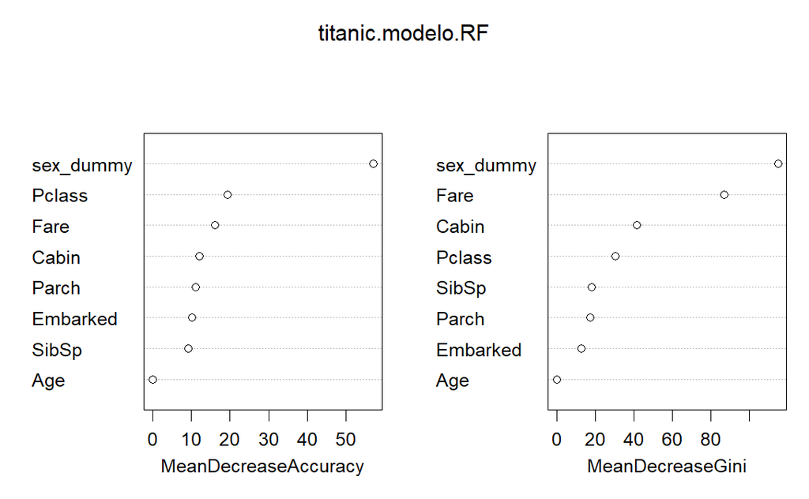

```r
titanic.treino$Survived <- as.factor(titanic.treino$Survived)

# Setando uma semente
set.seed(1234)

#Criando um modelo
titanic.modelo.RF <- randomForest(formula = Survived~ Pclass+sex_dummy+Age+SibSp+
                                    Parch+Fare+Cabin+Embarked,
                                  data = titanic.treino, ntree = 100, mtry = sqrt(length(titanic.treino)),
                                  importance = T)
varImpPlot(titanic.modelo.RF)
```

```r
NA
NA
```

### **6.1 Avaliando as métricas do modelo Random Forest**

Uma vez o modelo criado usando os dados treino o próximo passo é avaliar a acurácia do modelo e seus erros. Para isso os dados de teste serão empregados afim de obter métricas estatísticas do modelo. Importante para essa etapa é saber o quanto o modelo acertou e o quanto errou, ou seja falsos positivos e falsos negativos e verdadeiros positivos e verdadeiros negativos. Resumindo é necessário testar o modelo com os dados de teste e ver se o mesmo foi capaz de acertar as sua classificação. Para isso será utilizado o pacote [caret](https://cran.r-project.org/web/packages/caret/caret.pdf).

```r
library(caret)
set.seed(1234)
titanic.modelo.RF.predito <- predict(titanic.modelo.RF, titanic.teste)



## Matriz de confusão do Random Forest
titanic.gender.submission <- read.csv("gender_submission.csv")
titanic.teste$Survived <- as.factor(titanic.gender.submission$Survived)

matriz_confusao_RF <- confusionMatrix(data = titanic.modelo.RF.predito,
                                      reference = titanic.teste$Survived)
matriz_confusao_RF
```

```
Confusion Matrix and Statistics

          Reference
Prediction   0   1
         0 259  48
         1   7 104

               Accuracy : 0.8684
                 95% CI : (0.8322, 0.8993)
    No Information Rate : 0.6364
    P-Value [Acc > NIR] : < 2.2e-16

                  Kappa : 0.6983

 Mcnemar's Test P-Value : 6.906e-08

            Sensitivity : 0.9737
            Specificity : 0.6842
         Pos Pred Value : 0.8436
         Neg Pred Value : 0.9369
             Prevalence : 0.6364
         Detection Rate : 0.6196
   Detection Prevalence : 0.7344
      Balanced Accuracy : 0.8289

       'Positive' Class : 0
```

Por fim salvar um arquivo csv com as duas colunas e submeter no kaggle.

```r
write.csv(titanic.kaggle_RF, file="titanic_kaggle_RF.csv",append = F,sep = ",",
          col.names = c("PassengerId","Survived"),row.names = F )
```